# Reparameterizing Bayesian state-space models for more reliable fits

## Objective

Translate nonlinear state-space model from BUGS to Stan and diagnose potential problems in the posterior.

Model from two papers:

- Meyer, Renate and Russell B. Millar. 1999. BUGs in Bayesian Stock assessments. *Canadian Journal of Fisheries and Aquatic Sciences*. 56:1078-1086.
- Millar, Russell B. and Renate Meyer. 2000. Non-linear state space modelling of fisheries biomass dynamics by using Metropolis-Hastings within-Gibbs sampling. *Applied Statistics*. 49, Part 3: 327-342.

## Model: Data

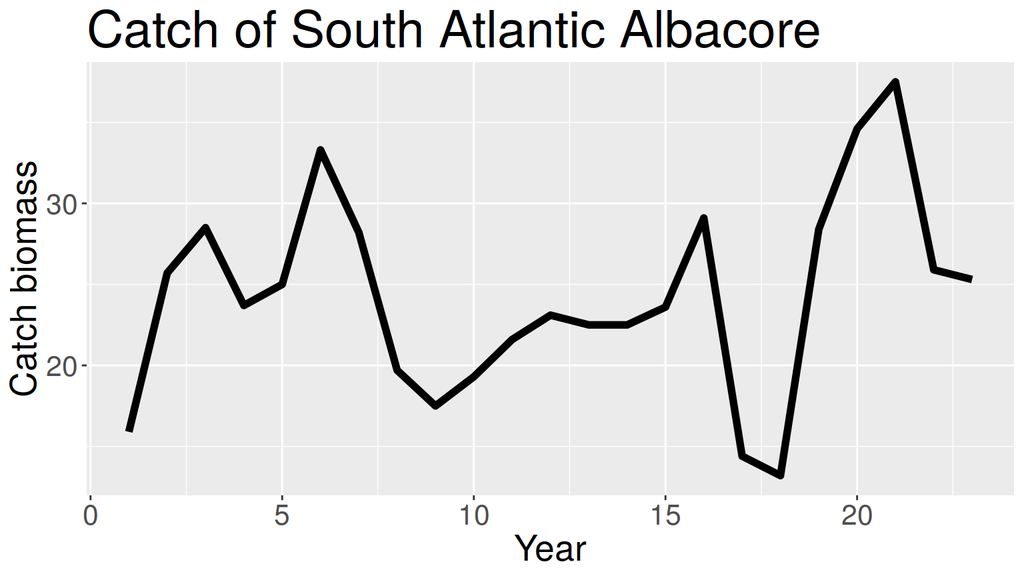

## Model: Data

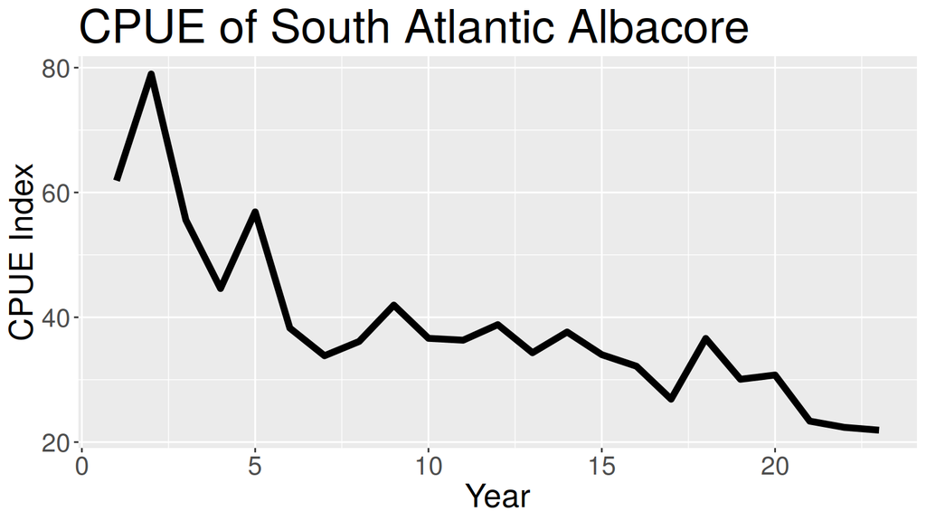

## Model: Observation

\(I_t\) is an index of biomass \(B_t\). These are related through the parameter \(q\), catchability.

\[I_t = q B_t.\]

Nondimensionalizing \(B_t\) against carrying capacity \(K\) gives \(P_t = B_t / K\), observed with log-normal noise with standard deviation \(\tau\).

\[\begin{aligned} I_t \mid P_t,q,\tau^2 &= q K P_t e^{v_t}\\ v_t &\sim \operatorname{Normal}(0, \tau^2). \end{aligned}\]

## Model: Population dynamics

- Schaefer dynamics
- Intrinsic growth rate \(r\)
- log-Normal error with sd \(\sigma\)
- \(P_1\) near \(1\)

\[\begin{aligned} P_1 \mid \sigma^2 &= e^{u_1}\\ P_t \mid P_{t-1},K,r,\sigma^2 &= \left[ P_{t-1} + r P_{t-1}(1 - P_{t-1}) - \frac{C_{t-1}}{K} \right]e^{u_t}\\ u_t &\sim \operatorname{Normal}(0, \sigma^2), \end{aligned}\]

## Model: Priors

All but \(q\) at least somewhat informative, based on literature review. Specified \(\log(q) \sim \operatorname{Flat}\).

\[\begin{aligned} r &\sim \operatorname{log Normal}(-1.38, 0.51^2)\\ K &\sim \operatorname{log Normal}(5.04, 0.5162^2)\\ p(q) &\propto 1/q\\ \sigma^2 &\sim \operatorname{Inverse Gamma}(3.79, 0.0102)\\ \tau^2 &\sim \operatorname{Inverse Gamma}(1.71, 0.0086). \end{aligned}\]

## Model: BUGs Approximations

- Truncated priors
- Approximate \(p(q)\) with inverse-gamma.
- Problems in Stan

[figure not shown]

## Stan: No-U-Turn Sampler

- Hamiltonian dynamics
- Self-tuning

[NUTS Simulator](https://chi-feng.github.io/mcmc-demo/app.html#EfficientNUTS,banana)

- **Divergences**: too much curvature
- **Max treedepth exceeded**: too flat

## Comparing model parameterizations

- Truncated: Original BUGs model fit in Stan
- Centered
- Noncentered Normal process errors
- Marginalized \(q\)
- Explicit fishing mortality

## Noncentered Normal process errors

\[\begin{aligned} P_1 \mid \sigma^2 &= \exp(u_1 \sigma)\\ P_t \mid P_{t-1},\dots &= \bigg[ P_{t-1} + r P_{t-1}(1 - P_{t-1}) \\ & \quad \quad \quad \quad - \frac{C_{t-1}}{K} \bigg] \exp(u_t \sigma)\\ u_t &\sim \operatorname{Normal}(0, 1) \end{aligned}\]

## Marginalized \(q\)

\[\begin{aligned} Z_i &= \log\left( \frac{I_i}{P_i K} \right)\\ \hat{q}' &= \frac{1}{n} \sum_i Z_i\\ Z_i &\sim \operatorname{Normal}(\hat{q}', \tau^2) \end{aligned}\]

From Walters & Ludwig (1994), *Calculation of Bayes posterior probability distributions for key populations parameters*.

## Explicit F parameterization

\[\begin{aligned} C^*_t = &\exp(-F_t) K P_t\\ C_t \sim &\operatorname{Normal}(C^*_t, \xi^2)\\ P_1 \mid \sigma^2 = &e^{u_1}\\ P_t \mid P_{t-1},\dots = &\left[ P_{t-1} + r P_{t-1}(1 - P_{t-1})\right]\\ &\times (1 - \exp(-F_{t-1}))\\ &\times \exp(u_t)\\ u_t &\sim \operatorname{Normal}(0, \sigma^2)\\ \end{aligned}\]

## Explicit F parameterization

\[\begin{aligned} C^*_t = &\exp(-F_t) K \left[P_t + r P_t (1 - P_t)\right]\\ C_t \sim &\operatorname{Normal}(C^*_t, \xi^2)\\ P_1 \mid \sigma^2 = &e^{u_1}\\ P_t \mid P_{t-1},\dots = &\left[ P_{t-1} + r P_{t-1}(1 - P_{t-1})\right]\\ &\times (1 - \exp(-F_{t-1}))\\ &\times \exp(u_t)\\ u_t &\sim \operatorname{Normal}(0, \sigma^2)\\ \end{aligned}\]

## Run specifications

- \(4\) chains
- \(10,000\) iterations
- \(5,000\) warmup iterations
- \(20,000\) inference iterations

## Results: Full series diagnostics

|  | Exc Treedepth | Exc Treedepth Adj | Divergences | Divergences Adj |
| --- | --- | --- | --- | --- |
| Truncated | 0 |  | **14648** |  |
| Centered | 0 | 0 | 13 | 0 |
| Noncentered | 35 | 7129 | 146 | 4 |
| Marginal q | 0 | 0 | 46 | 0 |
| Marginal q noncen | 0 | 10000 | 1377 | 74 |
| Explicit F | **0** |  | **0** |  |

## Results: Timing, unadjusted

|  | Warmup | Sample | **Min ESS Rate** | Exp ESS Rate |
| --- | --- | --- | --- | --- |
| Truncated | 70.23090 | 98.18090 | 3.906744 | 35.44550 |
| Centered | 51.19540 | 65.79570 | 26.277666 | 144.48313 |
| Noncentered | 243.05640 | 319.75060 | 8.190027 | 43.82854 |
| Marginal q | 26.14032 | 29.08037 | 112.765388 | 212.77523 |
| Marginal q noncen | 113.46060 | 69.48735 | 71.652046 | 153.68737 |
| Explicit F | 568.81600 | 748.31700 | 2.576744 | 12.60228 |

## Results: Timing, adjusted

|  | Warmup | Sample | **Min ESS Rate** | Exp ESS Rate |
| --- | --- | --- | --- | --- |
| Centered adj | 107.3862 | 98.9370 | 26.8749951 | 93.581213 |
| Noncentered adj | 523.3630 | 478.9535 | 5.2734152 | 29.525013 |
| Marginal q adj | 50.6163 | 54.0521 | 49.5456796 | 83.580600 |
| Marginal q noncen adj | 369.1227 | 292.9353 | 0.0068717 | 1.192989 |
| Explicit F | 568.81600 | 748.31700 | 2.576744 | 12.60228 |

## Results: MSY

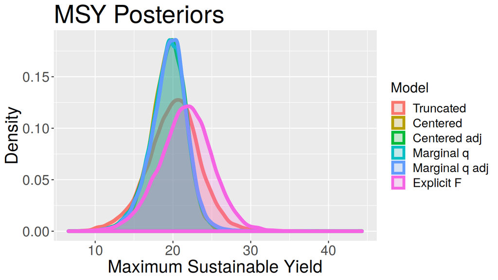

## Results: Catch error sensitivity

### Diagnostics

| Catch error | Exc max treedepth | Divergence | Min ESS | Par |
| --- | --- | --- | --- | --- |
| 0.010 | 614 | 0 | 1898.525 | `q` |
| 0.046 | 0 | 0 | 1784.530 | `q` |
| 0.22 | 0 | 0 | 1965.289 | `q` |
| 1.0 | 0 | 0 | 2021.433 | `q` |
| 4.6 | 0 | 19997 | 2.055 | `lp__` |
| 22 | 0 | 20000 | 2.012 | `K` |
| 100 | 0 | 20000 | 2.027 | `q` |

## Results: Catch error sensitivity

### Timing

| Catch error | Sampling (s) | Min ESS Rate |
| --- | --- | --- |
| 0.010 | 14065 | 0.134 |
| 0.046 | 2819 | 0.633 |
| 0.215 | 657 | 2.991 |
| 1.000 | 186 | 10.849 |
| 4.641 | 13 | 0.156 |
| 21.544 | 13 | 0.150 |
| 100.000 | 14 | 0.140 |

## Results: Catch error sensitivity

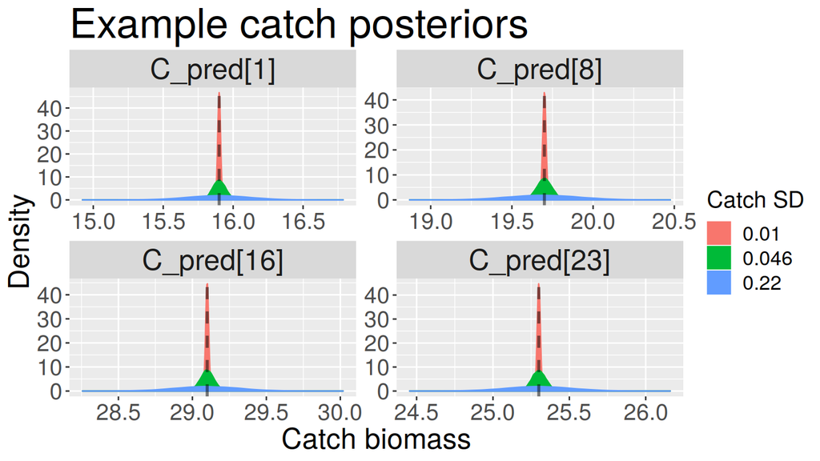

## Results: Catch error sensitivity

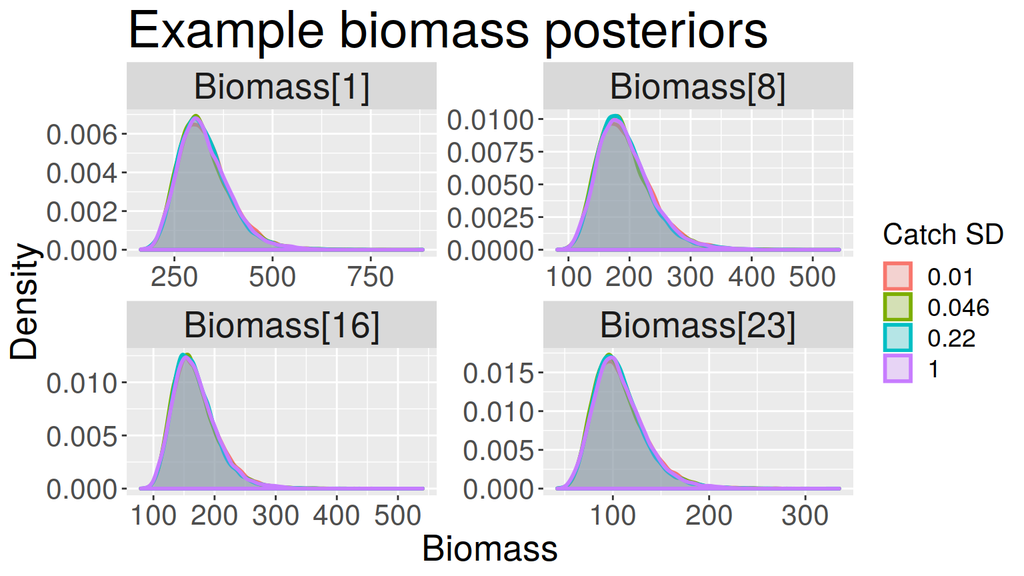

## Results: Catch error sensitivity

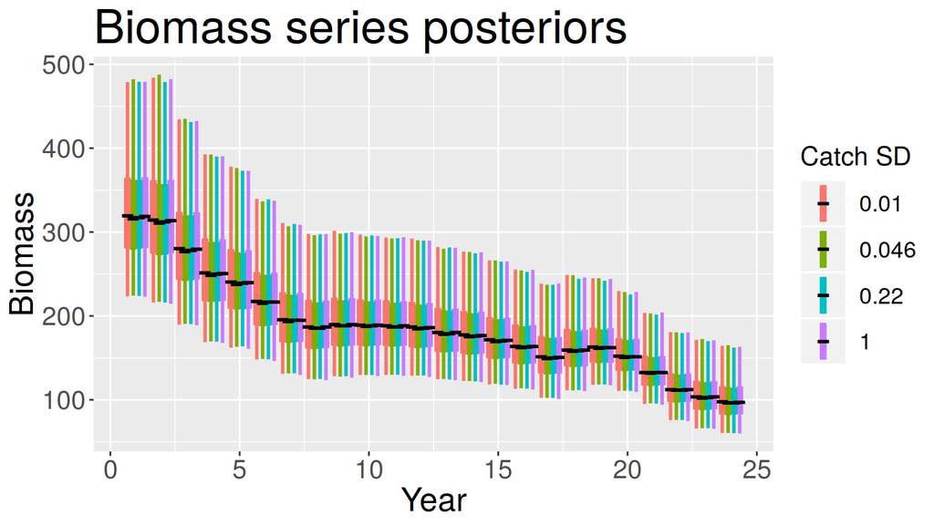

## Results: Catch error sensitivity

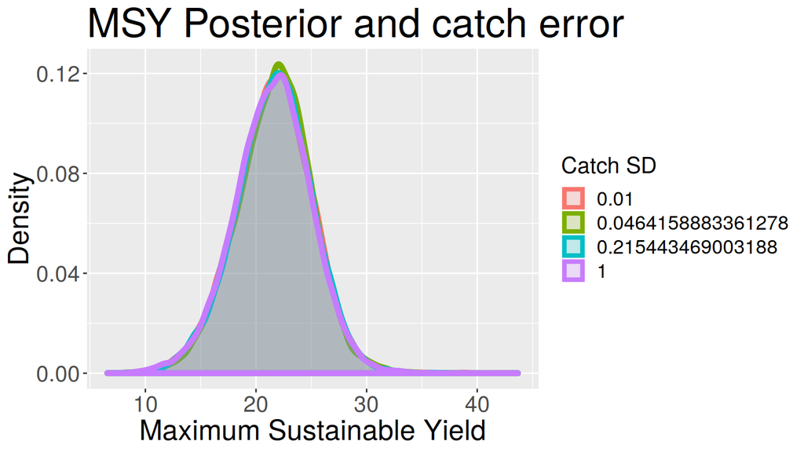